# phase_2_atliqo_bank

## Phase 2: AtliQ0 Bank Credit Card Project

### Business Analysis and launch of AB testing: Targeting Untapped Market

### Insights specific to customers with age group of 18 - 25

1. About 25% of the client base in the statistics is made up of people between the ages of 18 and 25.
2. This age group's average yearly salary is under $50,000.
3. Their credit score and maximum credit limit reflect the fact that they have little credit history.
4. Compared to other categories, the use of credit cards as a form of payment is comparatively low.
5. In comparison to other categories, the average credit card transaction amount is likewise low.
6. The top three product categories for shopping: Fashion & Clothing, Electronics, Beauty & Personal Care

[figure not shown]

## (1) Pre-Campaign

We would like to test out our new credit card. To do this, we must first determine how many clients we will need for our A/B testing. A control and test group will be established. Based on the statistical power and effect size that we decide upon after consulting with the business, we may determine the number of clients we require for each of these categories.

```python
#import required libraries
import statsmodels.stats.api as sms
import statsmodels.api as sm
import pandas as pd
import numpy as np
from scipy import stats as st
from matplotlib import pyplot as plt
import seaborn as sns
```

```python
alpha = 0.05
power = 0.8
effect_size=0.2

sms.tt_ind_solve_power(
    effect_size=0.2,
    alpha=alpha,
    power=power,
    ratio=1,
    alternative='two-sided'
)
```

```
393.4056989990351
```

393 clients are required for effect size 0.2. Budgetary constraints must be considered while implementing this campaign, so let's test it for various effect sizes and consult with the company to choose the best sample size.

```python
# Calculate the required sample size for different effect sizes
effect_sizes = [0.1, 0.2, 0.3, 0.4, 0.5,1]  #  standard deviations greater than control group

for effect_size in effect_sizes:
    sample_size = sms.tt_ind_solve_power(effect_size=effect_size, alpha=alpha, power=power, ratio=1, alternative='two-sided')
    print(f"Effect Size: {effect_size}, Required Sample Size: {int(sample_size)} customers")
```

```
Effect Size: 0.1, Required Sample Size: 1570 customers
Effect Size: 0.2, Required Sample Size: 393 customers
Effect Size: 0.3, Required Sample Size: 175 customers
Effect Size: 0.4, Required Sample Size: 99 customers
Effect Size: 0.5, Required Sample Size: 63 customers
Effect Size: 1, Required Sample Size: 16 customers
```

The test should be able to identify a difference between the control and test groups of at least 0.4 standard deviations, depending on business objectives. We require 100 clients for the effect size of 0.4, and after talking with the firm, we decided that 100 customers would be acceptable given their financial limits for this trial run.

#### Forming control and test groups

1. Approximately 246 clients between the ages of 18 and 25 have been identified. For the first campaign launch, we will choose 100 clients from this pool.
2. Based on an efficient size estimate and cost budgeting, the campaign is launched for 100 clients and will run for two months.
3. Achieved a conversion rate of about 40%, meaning that 40 out of 100 test group clients began using credit cards.
4. A control group of 40 clients will be established in order to keep the sample size comparable. Crucially, the first 100 clients chosen as the test group will not be allowed to join this control group.
5. As of present, each of the control and test groups has 40 clients.

##### We acquired daily data at the conclusion of the two-month campaign period that displayed the average transaction amounts made by all 40 clients in the control and test groups using their respective newly introduced and pre-existing credit cards.

##### The goal of this AB test's key performance indicator (KPI) is to increase the typical transaction amounts made possible by the new card.

## (2) Post-Campaign

## Two Sample Z Test for Our Hypothesis Testing

```python
# Loading campaign results data
df = pd.read_csv('data/avg_transactions_after_campaign.csv')
df.head(4)
```

|  | campaign_date | control_group_avg_tran | test_group_avg_tran |
| --- | --- | --- | --- |
| 0 | 2023-09-10 | 259.83 | 277.32 |
| 1 | 2023-09-11 | 191.27 | 248.68 |
| 2 | 2023-09-12 | 212.41 | 286.61 |
| 3 | 2023-09-13 | 214.92 | 214.85 |

```python
df.shape
```

```
(62, 3)
```

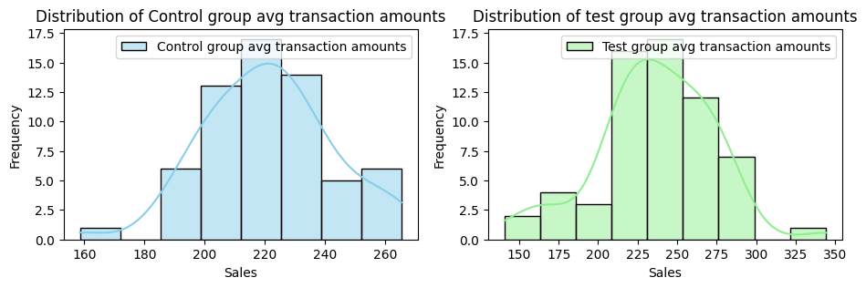

```python
# Let's look at distributions of avg transactions amounts in both groups

fig, (ax1, ax2) = plt.subplots(1, 2, figsize=(11, 3))

# Plot the distribution of Campaign A Sales
sns.histplot(df['control_group_avg_tran'], kde=True, color='skyblue', label='Control group avg transaction amounts', ax=ax1)
ax1.set_xlabel('Sales')
ax1.set_ylabel('Frequency')
ax1.set_title('Distribution of Control group avg transaction amounts')
ax1.legend()

# Plot the distribution of Campaign B Sales
sns.histplot(df['test_group_avg_tran'], kde=True, color='lightgreen', label='Test group avg transaction amounts', ax=ax2)
ax2.set_xlabel('Sales')
ax2.set_ylabel('Frequency')
ax2.set_title('Distribution of test group avg transaction amounts')
ax2.legend()

# Show the plots
plt.show()
```

#### Perform Hypothesis Testing Using Two Sample Z-test

```python
control_mean = df["control_group_avg_tran"].mean().round(2)
control_std = df["control_group_avg_tran"].std().round(2)
control_mean, control_std
```

```
(221.18, 21.36)
```

```python
test_mean = df["test_group_avg_tran"].mean().round(2)
test_std = df["test_group_avg_tran"].std().round(2)
test_mean, test_std
```

```
(235.98, 36.66)
```

```python
sample_size = df.shape[0]
sample_size
```

```
62
```

### Test Using Rejection Region (i.e. Critical Z Value)

```python
a = (control_std**2/sample_size)
b = (test_std**2/sample_size)

Z_score = (test_mean-control_mean)/np.sqrt(a+b)
Z_score
```

```
2.7466072001806734
```

```python
# For a significance level of 5% (0.05) in a right-tailed test, the critical Z-value is approximately 1.645
critical_z_value = st.norm.ppf(1 - alpha)  # Right-tailed test at 5% significance level
critical_z_value
```

```
1.6448536269514722
```

```python
Z_score > critical_z_value
```

```
True
```

Since Z score is higher than critical Z value, we can reject the null hypothesis.

### Test Using p-Value

```python
# Calculate the p-value corresponding to z score for a right-tailed test
p_value = 1 - st.norm.cdf(Z_score)
p_value
```

```
0.0030107601919702187
```

```python
p_value < alpha # p value is less than significance level of 5% (or 0.05 for absolute value)
```

```
True
```

Since p value is less than significance level (i.e. alpha), we can reject the null hypothesis.

### Using Ready Made API call

1.We will now use stats module from statmodels for doing Z-test

2.The order of passing control and test group data to sm.stats.ztest(test_data, control_data) defines the direction of the test and influences the test results.

3.When you pass test group data first, z-test module assumes that alternative hypothesis as mean of the test group is greater than the mean of the control group and conversely if you switch the order z-test module assumes alternative hypothesis as control group average is more than test group

5.By default z-test module in statmodels performs two tailed test. As we are doing one-tailed test in our case based on the direction and alternate hypothesis we have to set "alternative" parameter.

6.In out case based on test direction we will set "alternative" parameter to "larger"

```python
# Performing Z-test with above considerations
z_statistic, p_value = sm.stats.ztest( df['test_group_avg_tran'],df['control_group_avg_tran'],alternative = 'larger')
z_statistic, p_value
```

```
(2.7482973745691135, 0.002995282462202502)
```